# wineQualityWhite

# Multivariate Plots Section

### quality Vs alcohol and density

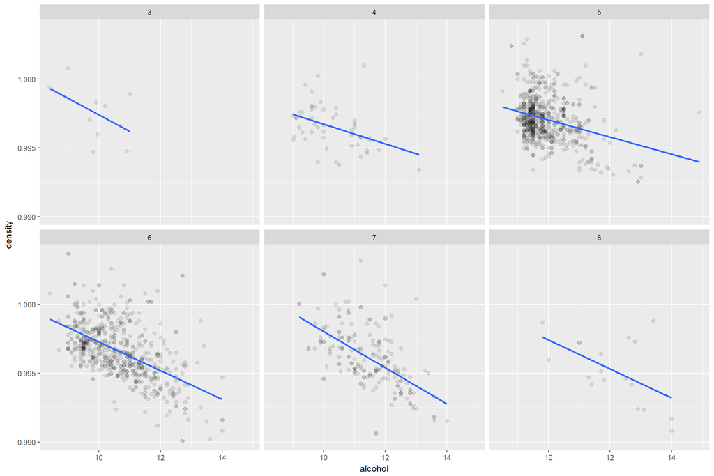

```
##   quality       corr
## 1       3 -0.4905907
## 2       4 -0.4242850
## 3       5 -0.2887623
## 4       6 -0.5471226
## 5       7 -0.5817180
## 6       8 -0.5434650
```

### quality Vs alcohol and density

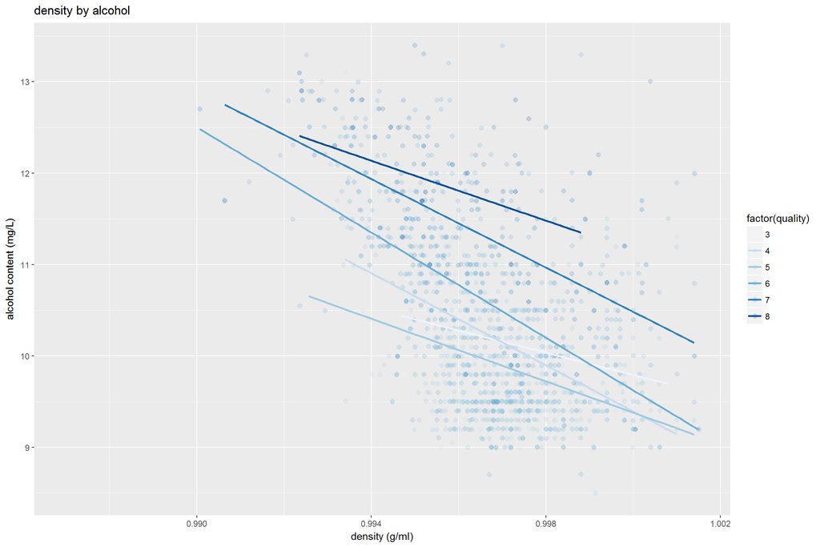

### quality Vs chlorides and total.sulfur.dioxide

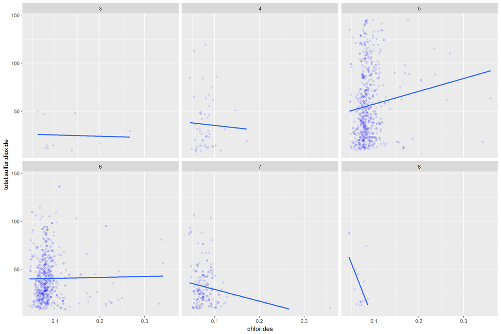

```
##   quality         corr
## 1       3 -0.053175516
## 2       4  0.140277576
## 3       5  0.062640872
## 4       6 -0.001604798
## 5       7 -0.223922490
## 6       8 -0.545540562
```

### quality Vs chlorides and total.sulfur.dioxide

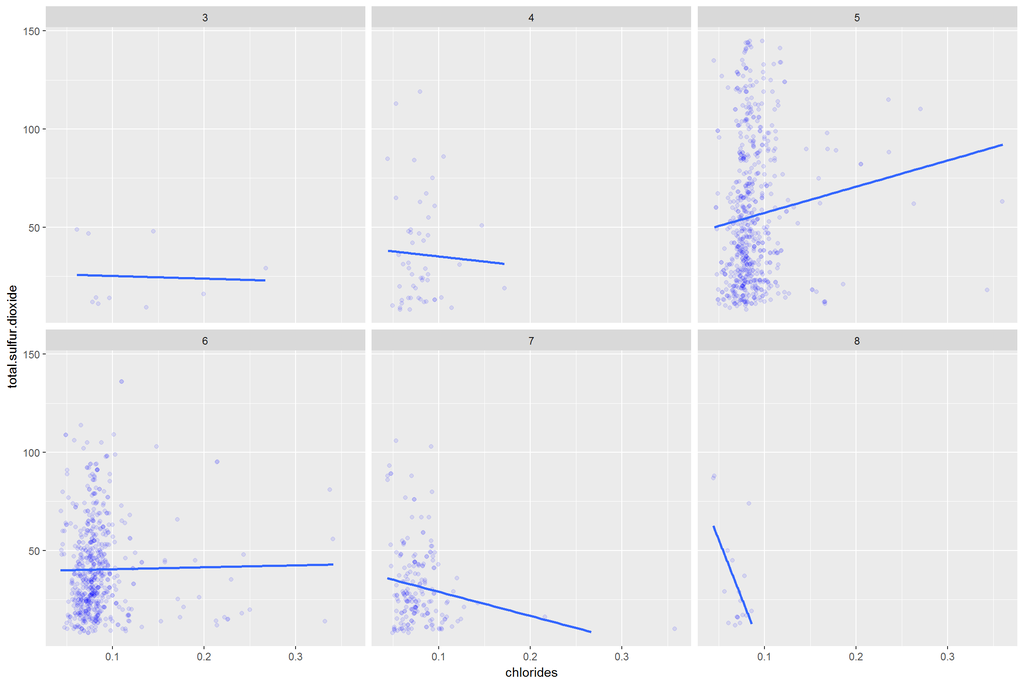

```
##   quality         corr
## 1       3 -0.053175516
## 2       4  0.140277576
## 3       5  0.062640872
## 4       6 -0.001604798
## 5       7 -0.223922490
## 6       8 -0.545540562
```

# Multivariate Analysis

### Talk about some of the relationships you observed in this part of the investigation. Were there features that strengthened each other in terms of looking at your feature(s) of interest?

1. From the plot we can see , higher quality(such as 7~8) wine more likely to appear on high acohol low density area.higher qualiyt wines’ correlation between alcohol and density appear to be more close to -1 , indicate that high quality wine must have less chemical ingredient that may influen density other than alcohol.

### Were there any interesting or surprising interactions between features?

### OPTIONAL: Did you create any models with your dataset? Discuss the strengths and limitations of your model.

#### Build a Linear Model

```
##
## Calls:
## m1: lm(formula = I(quality ~ alcohol), data = wqr)
## m2: lm(formula = quality ~ alcohol + density, data = wqr)
## m3: lm(formula = quality ~ alcohol + density + volatile.acidity,
##     data = wqr)
## m4: lm(formula = quality ~ alcohol + density + volatile.acidity +
##     chlorides, data = wqr)
## m5: lm(formula = quality ~ alcohol + density + volatile.acidity +
##     chlorides + total.sulfur.dioxide, data = wqr)
##
## ===================================================================================
##                            m1          m2          m3          m4          m5
## -----------------------------------------------------------------------------------
##   (Intercept)            1.875***  -33.152**   -18.407     -19.637     -18.149
##                         (0.175)    (10.878)    (10.298)    (10.352)    (10.318)
##   alcohol                0.361***    0.391***    0.333***    0.330***    0.317***
##                         (0.017)     (0.019)     (0.018)     (0.019)     (0.019)
##   density                           34.822**    21.360*     22.660*     21.385*
##                                    (10.813)    (10.228)    (10.289)    (10.253)
##   volatile.acidity                              -1.365***   -1.362***   -1.350***
##                                                 (0.096)     (0.096)     (0.095)
##   chlorides                                                 -0.422      -0.416
##                                                             (0.366)     (0.364)
##   total.sulfur.dioxide                                                  -0.002***
##                                                                         (0.001)
## -----------------------------------------------------------------------------------
##   R-squared                  0.2        0.2         0.3         0.3         0.3
##   adj. R-squared             0.2        0.2         0.3         0.3         0.3
##   sigma                      0.7        0.7         0.7         0.7         0.7
##   F                        468.3      240.7       248.9       187.0       153.6
##   p                          0.0        0.0         0.0         0.0         0.0
##   Log-likelihood         -1721.1    -1715.9     -1619.6     -1619.0     -1612.0
##   Deviance                 805.9      800.7       709.9       709.3       703.1
##   AIC                     3448.1     3439.8      3249.3      3249.9      3238.0
##   BIC                     3464.2     3461.3      3276.1      3282.2      3275.7
##   N                       1599       1599        1599        1599        1599
## ===================================================================================
```

# Final Plots and Summary

### Plot One

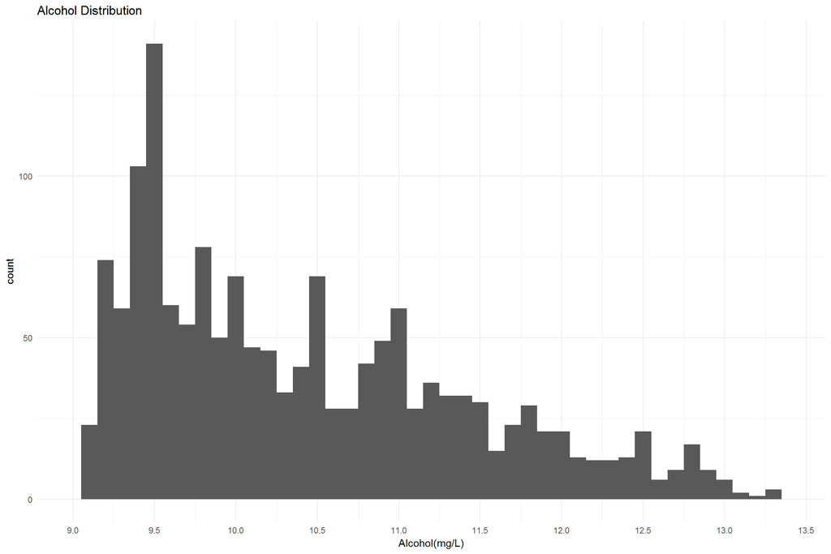

```
##
##   (8.5,9]   (9,9.5]  (9.5,10] (10,10.5] (10.5,11] (11,11.5] (11.5,12]
##        34       399       311       236       208       158       109
## (12,12.5] (12.5,13] (13,13.5]
##        71        47        10
```

### Description One

We can easily found that the alcohol distribution were right skew.